# Assess BRAF fusion breakpoints in PBTA ancestry cohort

Ryan Corbett, Jo Lynne Rokita

2024

This script calculates frequency of BRAF fusion breakpoint types by predicted ancestry in pLGG, BRAF fusion subtype patients in the PBTA ancestry cohort

Load libraries and set directories

```r
library(data.table)
library(tidyverse)
```

```r
library(ComplexHeatmap)
library(circlize)
root_dir <- rprojroot::find_root(rprojroot::has_dir(".git"))

data_dir <- file.path(root_dir, "data")
analysis_dir <- file.path(root_dir, "analyses", "braf-fusions")
results_dir <- file.path(analysis_dir, "results")
input_dir <- file.path(analysis_dir, "input")
plot_dir <- file.path(analysis_dir, "plots")

source(file.path(analysis_dir, "util", "heatmap_function.R"))
```

Set file paths

```r
fusion_file <- file.path(results_dir, "braf-fusions-exon-annotation.tsv")

fusion_dgd_file <- file.path(data_dir, "fusion-dgd.tsv.gz")

cohort_hist_file <- file.path(root_dir, "analyses", "survival", "results", "merged_ancestry_histology_survival.tsv")

hist_file <- file.path(data_dir, "histologies.tsv")
```

Load data

```r
braf_hist <- read_tsv(cohort_hist_file) %>%
  dplyr::filter(plot_group == "Low-grade glioma" & (grepl("-BRAF|wildtype|classified", molecular_subtype) | is.na(molecular_subtype))) %>%
  dplyr::mutate(predicted_ancestry = factor(predicted_ancestry))
hist <- read_tsv(hist_file)
# filter fusion file for in-frame fusions and duplications, and determine whether BRAF kinase domain is retained
braf_fusions <- read_tsv(fusion_file) %>%
  dplyr::filter(Fusion_Type == "in-frame",
         grepl("duplication", annots)) %>%
  mutate(keep = case_when(FusionName == "KIAA1549--BRAF" & DomainRetainedGene1B == "Yes" ~ "yes",
                          FusionName == "BRAF--KIAA1549" & DomainRetainedGene1A == "Yes" ~ "yes",
                          TRUE ~ "no")) %>%
  # The below samples have two different common breakpoints and one is low conf in arriba, so we will remove that one
  mutate(keep = case_when(Sample %in% c("BS_SDZY6RZ3", "BS_063ERW0R") & LeftBreakpoint_position == 138867975 ~ "no",
                            TRUE ~ keep))
braf_fusions_dgd <- read_tsv(fusion_dgd_file) %>%
  dplyr::filter(FusionName == "KIAA1549--BRAF" & !grepl("Tier 3|Tier 4", variant_tier)) %>%
  dplyr::rename(Kids_First_Biospecimen_ID = Sample) %>%
  dplyr::select(Kids_First_Biospecimen_ID, FusionName, `5_prime_region`, `3_prime_region`) %>%
  dplyr::mutate(`5_prime_region` = gsub("^Exon |^exon ", "", `5_prime_region`),
         `3_prime_region` = gsub("^Exon |^exon ", "", `3_prime_region`),
         breakpoint_exons = paste(`5_prime_region`, `3_prime_region`, sep = ":")) %>%
    # re-format exon numbers to match those in pbta fusion file
  dplyr::mutate(breakpoint_exons = str_replace(
                                              str_replace(breakpoint_exons,
                                               ":8", ":08"),
                                              ":9", ":09"),
         breakpoint_type = case_when(breakpoint_exons %in% c("16:09", "15:09", "16:11", "18:10") ~ "common",
                                     TRUE ~ "rare/novel"),
         keep = "yes") %>%
  left_join(hist[,c("Kids_First_Participant_ID", "Kids_First_Biospecimen_ID")])
```

Consolidate all common and rare exon breakpoints per patient

```r
common_fusions_pbta <- braf_fusions %>%
  dplyr::filter(breakpoint_exons %in% c("16:09", "15:09", "16:11", "18:10") & keep == "yes") %>%
  distinct(Kids_First_Participant_ID, breakpoint_exons, .keep_all = T) %>%
  group_by(Kids_First_Participant_ID) %>%
  summarise(breakpoint_exons_common = str_c(breakpoint_exons, collapse = ";"))

common_fusions <- braf_fusions_dgd %>%
  dplyr::filter(breakpoint_exons %in% c("16:09", "15:09", "16:11", "18:10") & keep == "yes") %>%
  distinct(Kids_First_Participant_ID, breakpoint_exons, .keep_all = T) %>%
  group_by(Kids_First_Participant_ID) %>%
  summarise(breakpoint_exons_common = str_c(breakpoint_exons, collapse = ";")) %>%
  bind_rows(common_fusions_pbta) %>%
  distinct(Kids_First_Participant_ID, breakpoint_exons_common, .keep_all = T) %>%
  group_by(Kids_First_Participant_ID) %>%
  summarise(breakpoint_exons_common = str_c(breakpoint_exons_common, collapse = ";"))

rare_novel_fusions_pbta <- braf_fusions %>%
  dplyr::filter(!breakpoint_exons %in% c("16:09", "15:09", "16:11", "18:10") & keep == "yes") %>%
  distinct(Kids_First_Participant_ID, breakpoint_exons, .keep_all = T) %>%
  group_by(Kids_First_Participant_ID) %>%
  summarise(breakpoint_exons_rare = str_c(breakpoint_exons, collapse = ";"))

rare_novel_fusions <- braf_fusions_dgd %>%
  dplyr::filter(!breakpoint_exons %in% c("16:09", "15:09", "16:11", "18:10") & keep == "yes") %>%
  distinct(Kids_First_Participant_ID, breakpoint_exons, .keep_all = T) %>%
  group_by(Kids_First_Participant_ID) %>%
  summarise(breakpoint_exons_rare = str_c(breakpoint_exons, collapse = ";")) %>%
  bind_rows(rare_novel_fusions_pbta) %>%
  distinct(Kids_First_Participant_ID, breakpoint_exons_rare, .keep_all = T) %>%
  group_by(Kids_First_Participant_ID) %>%
  summarise(breakpoint_exons_rare = str_c(breakpoint_exons_rare, collapse = ";"))

fusions_all <- common_fusions %>%
  bind_rows(rare_novel_fusions) %>%
  dplyr::mutate(breakpoint_type = case_when(
    !is.na(breakpoint_exons_common) & !is.na(breakpoint_exons_rare) ~ NA_character_,
    !is.na(breakpoint_exons_rare) ~ "rare",
    !is.na(breakpoint_exons_common) ~ "common",
    TRUE ~ NA_character_
  )) %>%
  # Assign breakpoint group (unique common breakpoint or broad rare group)
  dplyr::mutate(breakpoint_group = case_when(
    !is.na(breakpoint_exons_common) & !is.na(breakpoint_exons_rare) ~ NA_character_,
    breakpoint_exons_common == "16:09" ~ "16:09",
    breakpoint_exons_common == "15:09" ~ "15:09",
    breakpoint_exons_common == "16:11" ~ "16:11",
    breakpoint_exons_common == "18:10" ~ "18:10",
    !is.na(breakpoint_exons_rare) ~ "rare",
    TRUE ~ NA_character_
  )) %>%
  write_tsv(file.path(results_dir, "braf-fusion-breakpoints-by-patient.tsv"))
```

Merge breakpoint data to braf hist

```r
# add high conf methylation subtypes to the braf hist
scores <- hist %>%
  filter(dkfz_v12_methylation_subclass_score >= 0.8,
         # grab only PA subtypes
         grepl("PA_", dkfz_v12_methylation_subclass)) %>%
  dplyr::select("match_id", "dkfz_v12_methylation_subclass") %>%
  group_by(match_id) %>%
  summarise(dkfz_v12_methylation_subclass = str_c(unique(dkfz_v12_methylation_subclass), collapse = ";")) %>%
  unique()

braf_hist <- braf_hist %>%
  dplyr::rename(Kids_First_Biospecimen_ID_normal = Kids_First_Biospecimen_ID,
                Kids_First_Biospecimen_ID = Kids_First_Biospecimen_ID_tumor) %>%
  left_join(fusions_all) %>%
  dplyr::filter(!is.na(breakpoint_type)) %>%
  left_join(hist[,c("Kids_First_Biospecimen_ID", "match_id")]) %>%
  left_join(scores)
```

How many patients do we have breakpoint data for?

```r
nrow(braf_hist)
```

```
## [1] 172
```

```r
round(table(braf_hist$predicted_ancestry, braf_hist$breakpoint_type)/as.vector(table(braf_hist$predicted_ancestry)) * 100, 2)
```

```
##
##       common   rare
##   AFR  95.83   4.17
##   AMR  87.50  12.50
##   EAS 100.00   0.00
##   EUR  93.97   6.03
##   SAS 100.00   0.00
```

## Common breakpoint summary

What is the distribution of common breakpoints by ancestry?

```r
table(braf_hist$breakpoint_exons_common, braf_hist$predicted_ancestry)
```

```
##
##         AFR AMR EAS EUR SAS
##   15:09   4   3   2  19   3
##   16:09  15  14   1  73   1
##   16:11   4   3   0  12   1
##   18:10   0   1   0   5   0
```

Calculate fusion breakpoint frequency by predicted ancestry and Fisher’s exact test p-value

```r
common_breakpoints <- c("16:09", "15:09", "16:11", "18:10")

common_df <- braf_hist %>%
  dplyr::filter(breakpoint_exons_common %in% common_breakpoints) %>%
  group_by(breakpoint_exons_common, predicted_ancestry) %>%
  summarise(count = n()) %>%
  group_by(predicted_ancestry) %>%
  mutate(total_count = sum(count),
         percentage = round(count / total_count * 100, 1)) %>%
  dplyr::mutate(ct_perc = glue::glue("{count} ({percentage}%)")) %>%
  dplyr::select(breakpoint_exons_common, predicted_ancestry, ct_perc) %>%
  spread(predicted_ancestry, ct_perc, fill = 0)
common_df <- common_df %>%
  mutate(
    p = map_dbl(breakpoint_exons_common, ~round(fisher.test(table(grepl(.x, braf_hist$breakpoint_exons_common), braf_hist$predicted_ancestry))$p.value, 4))
  )

write_tsv(common_df,
          file.path(results_dir, "lgg-braf-fusion-common-breakpoint-freq.tsv"))
```

Calculate breakpoint group odds ratios and p-values across predicted ancestries, and plot

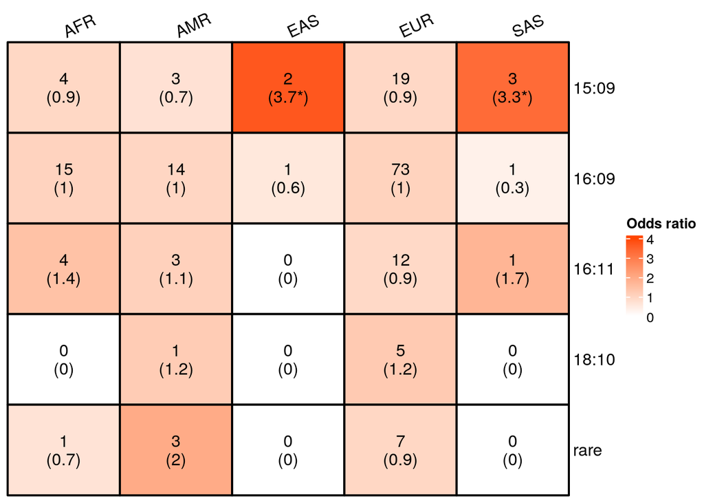

```r
group_ht <- plot_enr(braf_hist,
                     "breakpoint_group", "predicted_ancestry",
                     var2_names = c("AFR", "AMR", "EAS", "EUR", "SAS"),
                     var1_names = c("15:09", "16:09", "16:11", "18:10", "rare"),
                     padjust = TRUE)

# plot enrichment results
pdf(file.path(plot_dir, "breakpoint_group_ancestry_ct_enr_heatmap.pdf"),
    height = 3, width = 4)

draw(group_ht)

invisible(dev.off())

draw(group_ht)
```

Print rare/novel fusion breakpoint count by predicted ancestry

```r
table(braf_hist$breakpoint_exons_rare, braf_hist$predicted_ancestry)
```

```
##
##         AFR AMR EAS EUR SAS
##   10:09   0   0   0   1   0
##   13:09   0   2   0   0   0
##   13:11   0   0   0   1   0
##   14:08   1   0   0   0   0
##   15:11   0   0   0   4   0
##   16:10   0   0   0   1   0
##   19:09   0   1   0   0   0
```

Create heatmap of rare breakpoints by ancestry

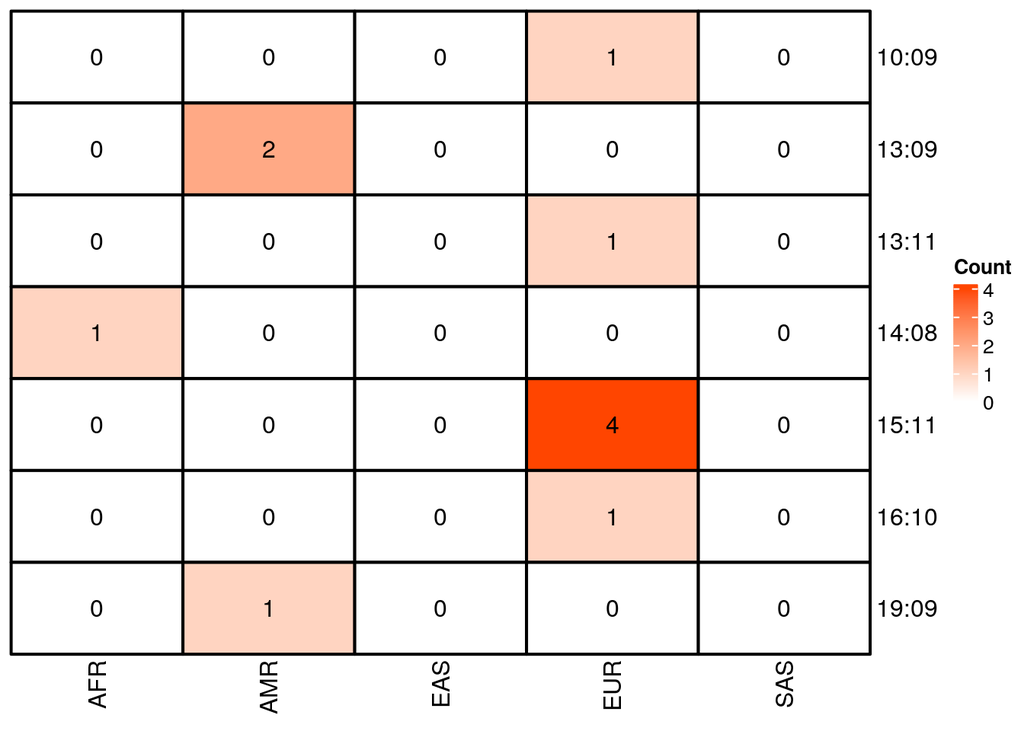

```r
pdf(file.path(plot_dir, "rare_breakpoints_by_ancestry.pdf"),
    height = 3, width = 4)

rare_ct <- table(braf_hist$breakpoint_exons_rare[!is.na(braf_hist$breakpoint_exons_rare)],
                 braf_hist$predicted_ancestry[!is.na(braf_hist$breakpoint_exons_rare)])

col_fun = colorRamp2(c(0, ceiling(max(rare_ct))), c("white", "orangered"))

rare_ht <- Heatmap(rare_ct,
            name = "Count",
            cluster_rows = F,
            cluster_columns = F,
            rect_gp = gpar(col = "black", lwd = 2),
            col = col_fun,
            cell_fun = function(j, i, x, y, width, height, fill) {
              grid.text(sprintf("%s", rare_ct[i, j]), x, y, gp = gpar(fontsize = 12))
            })

rare_ht

invisible(dev.off())

rare_ht
```

Print ancestry by methyl subtype

```r
table(braf_hist$dkfz_v12_methylation_subclass, braf_hist$predicted_ancestry)
```

```
##
##               AFR AMR EAS EUR SAS
##   PA_CORT       0   0   0   1   0
##   PA_INF        9   8   0  43   1
##   PA_INF_FGFR   0   0   0   1   0
##   PA_MID        1   2   1   8   1
```

Print breakpoint by methyl subtype

```r
table(braf_hist$breakpoint_type, braf_hist$dkfz_v12_methylation_subclass)
```

```
##
##          PA_CORT PA_INF PA_INF_FGFR PA_MID
##   common       1     61           1     10
##   rare         0      0           0      3
```

```r
fisher.test(table(braf_hist$breakpoint_type, braf_hist$dkfz_v12_methylation_subclass), simulate.p.value = T)
```

```
##
##  Fisher's Exact Test for Count Data with simulated p-value (based on
##  2000 replicates)
##
## data:  table(braf_hist$breakpoint_type, braf_hist$dkfz_v12_methylation_subclass)
## p-value = 0.008996
## alternative hypothesis: two.sided
```

Print breakpoint by methyl subtype

```r
table(braf_hist$breakpoint_group, braf_hist$dkfz_v12_methylation_subclass)
```

```
##
##         PA_CORT PA_INF PA_INF_FGFR PA_MID
##   15:09       1      6           0      7
##   16:09       0     45           1      3
##   16:11       0      6           0      0
##   18:10       0      4           0      0
##   rare        0      0           0      3
```

```r
fisher.test(table(braf_hist$breakpoint_group, braf_hist$dkfz_v12_methylation_subclass), simulate.p.value = T)
```

```
##
##  Fisher's Exact Test for Count Data with simulated p-value (based on
##  2000 replicates)
##
## data:  table(braf_hist$breakpoint_group, braf_hist$dkfz_v12_methylation_subclass)
## p-value = 0.0009995
## alternative hypothesis: two.sided
```

Plot methyl subtype by breakpoint group

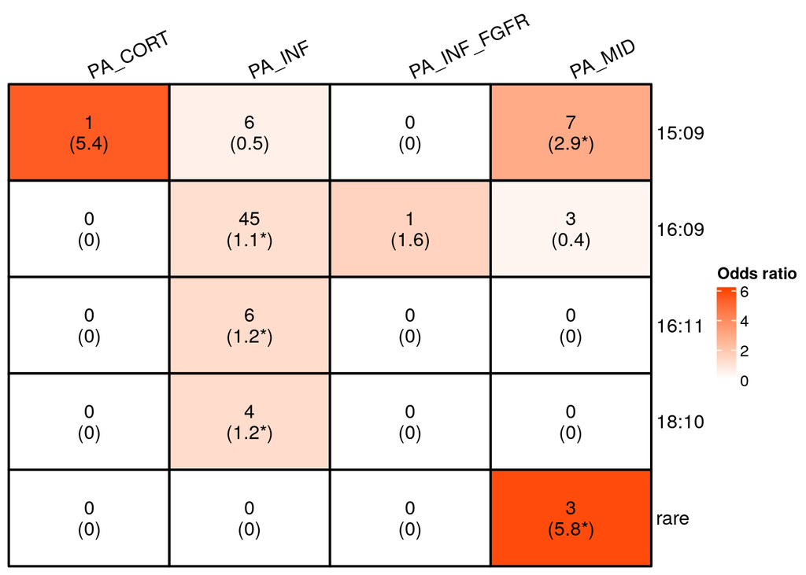

```r
methyl_ht <- plot_enr(braf_hist[!is.na(braf_hist$dkfz_v12_methylation_subclass),],
                     "breakpoint_group", "dkfz_v12_methylation_subclass",
                     var1_names = c("15:09", "16:09", "16:11", "18:10", "rare"),
                     var2_names = sort(unique(braf_hist$dkfz_v12_methylation_subclass)),
                     padjust = TRUE)

# plot enrichment results
pdf(file.path(plot_dir, "breakpoint_group_methyl_subtype_ct_enr_heatmap.pdf"),
    height = 3, width = 4)

draw(methyl_ht)

invisible(dev.off())

draw(methyl_ht)
```

Assess distribution of resection level in patients by breakpoint type (common vs. rare)

```r
round(table(braf_hist$breakpoint_type, braf_hist$extent_of_tumor_resection)/as.vector(table(braf_hist$breakpoint_type)), 2)
```

```
##
##          Biopsy only Gross/Near total resection Not Reported Partial resection
##   common        0.04                       0.69         0.01              0.27
##   rare          0.09                       0.18         0.00              0.73
```

```r
fisher.test(table(braf_hist$breakpoint_type, braf_hist$extent_of_tumor_resection))
```

```
##
##  Fisher's Exact Test for Count Data
##
## data:  table(braf_hist$breakpoint_type, braf_hist$extent_of_tumor_resection)
## p-value = 0.003016
## alternative hypothesis: two.sided
```

Assess distribution of resection level in patients by breakpoint group

```r
round(table(braf_hist$breakpoint_group, braf_hist$extent_of_tumor_resection)/as.vector(table(braf_hist$breakpoint_group)), 2)
```

```
##
##         Biopsy only Gross/Near total resection Not Reported Partial resection
##   15:09        0.06                       0.52         0.00              0.42
##   16:09        0.00                       0.75         0.01              0.24
##   16:11        0.20                       0.65         0.00              0.15
##   18:10        0.00                       0.67         0.00              0.33
##   rare         0.09                       0.18         0.00              0.73
```

```r
fisher.test(table(braf_hist$breakpoint_group, braf_hist$extent_of_tumor_resection), simulate.p.value = T)
```

```
##
##  Fisher's Exact Test for Count Data with simulated p-value (based on
##  2000 replicates)
##
## data:  table(braf_hist$breakpoint_group, braf_hist$extent_of_tumor_resection)
## p-value = 0.0004998
## alternative hypothesis: two.sided
```

Plot extent of tumor resection by breakpoint group

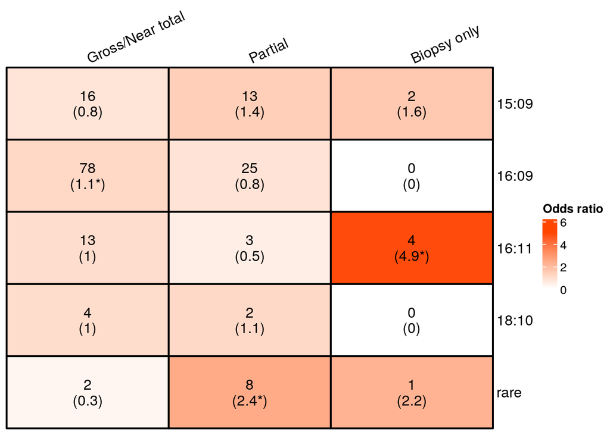

```r
braf_hist <- braf_hist %>%
  dplyr::mutate(resection = str_replace(extent_of_tumor_resection, " resection", ""))

resection_ht <- plot_enr(braf_hist[!grepl("Not Reported", braf_hist$resection),],
                     "breakpoint_group", "resection",
                     var1_names = c("15:09", "16:09", "16:11", "18:10", "rare"),
                     var2_names = c("Gross/Near total", "Partial", "Biopsy only"),
                     padjust = TRUE)

# plot enrichment results
pdf(file.path(plot_dir, "breakpoint_group_resection_ct_enr_heatmap.pdf"),
    height = 3, width = 4)

draw(resection_ht)

invisible(dev.off())

draw(resection_ht)
```

Assess distribution of tumor CNS region in patients by breakpoint type and group

```r
round(table(braf_hist$breakpoint_type, braf_hist$CNS_region)/as.vector(table(braf_hist$breakpoint_type)), 3) * 100
```

```
##
##          Hemispheric Midline Mixed Optic pathway Posterior fossa Spine
##   common         2.5     5.6   8.7           1.2            72.0   2.5
##   rare           9.1     0.0  18.2          18.2             9.1   0.0
##
##          Suprasellar Ventricles
##   common         4.3        3.1
##   rare          36.4        9.1
```

```r
fisher.test(table(braf_hist$breakpoint_type, braf_hist$CNS_region), simulate.p.value = T)
```

```
##
##  Fisher's Exact Test for Count Data with simulated p-value (based on
##  2000 replicates)
##
## data:  table(braf_hist$breakpoint_type, braf_hist$CNS_region)
## p-value = 0.0004998
## alternative hypothesis: two.sided
```

```r
round(table(braf_hist$breakpoint_group, braf_hist$CNS_region)/as.vector(table(braf_hist$breakpoint_group)), 3) * 100
```

```
##
##         Hemispheric Midline Mixed Optic pathway Posterior fossa Spine
##   15:09         3.2     3.2  19.4           0.0            45.2  12.9
##   16:09         2.9     7.7   2.9           1.0            80.8   0.0
##   16:11         0.0     0.0  20.0           5.0            70.0   0.0
##   18:10         0.0     0.0  16.7           0.0            66.7   0.0
##   rare          9.1     0.0  18.2          18.2             9.1   0.0
##
##         Suprasellar Ventricles
##   15:09        12.9        3.2
##   16:09         1.9        2.9
##   16:11         0.0        5.0
##   18:10        16.7        0.0
##   rare         36.4        9.1
```

```r
fisher.test(table(braf_hist$breakpoint_group, braf_hist$CNS_region), simulate.p.value = T)
```

```
##
##  Fisher's Exact Test for Count Data with simulated p-value (based on
##  2000 replicates)
##
## data:  table(braf_hist$breakpoint_group, braf_hist$CNS_region)
## p-value = 0.0004998
## alternative hypothesis: two.sided
```

Plot CNS region by breakpoint group

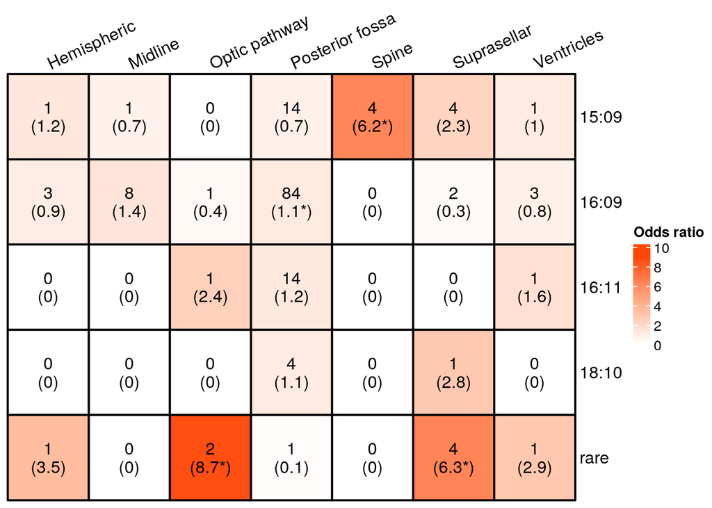

```r
region_ht <- plot_enr(braf_hist[braf_hist$CNS_region != "Mixed",],
                     "breakpoint_group", "CNS_region",
                     var1_names = c("15:09", "16:09", "16:11", "18:10", "rare"),
                     var2_names = sort(unique(braf_hist$CNS_region[braf_hist$CNS_region != "Mixed"])),
                     padjust = TRUE)

# plot enrichment results
pdf(file.path(plot_dir, "breakpoint_group_region_ct_enr_heatmap.pdf"),
    height = 3, width = 6.5)

draw(region_ht)

invisible(dev.off())

draw(region_ht)
```

Confirm that CNS region and degree of tumor resection are significantly associated:

```r
round(table(braf_hist$CNS_region, braf_hist$extent_of_tumor_resection)/as.vector(table(braf_hist$CNS_region)), 3) * 100
```

```
##
##                   Biopsy only Gross/Near total resection Not Reported
##   Hemispheric             0.0                       60.0          0.0
##   Midline                 0.0                       22.2          0.0
##   Mixed                  18.8                       25.0          0.0
##   Optic pathway          50.0                        0.0          0.0
##   Posterior fossa         0.9                       86.3          0.9
##   Spine                   0.0                        0.0          0.0
##   Suprasellar             9.1                        0.0          0.0
##   Ventricles              0.0                       50.0          0.0
##
##                   Partial resection
##   Hemispheric                  40.0
##   Midline                      77.8
##   Mixed                        56.2
##   Optic pathway                50.0
##   Posterior fossa              12.0
##   Spine                       100.0
##   Suprasellar                  90.9
##   Ventricles                   50.0
```

```r
fisher.test(table(braf_hist$CNS_region, braf_hist$extent_of_tumor_resection), simulate.p.value= T)
```

```
##
##  Fisher's Exact Test for Count Data with simulated p-value (based on
##  2000 replicates)
##
## data:  table(braf_hist$CNS_region, braf_hist$extent_of_tumor_resection)
## p-value = 0.0004998
## alternative hypothesis: two.sided
```

```r
hist <- read_tsv(file.path(data_dir, "histologies.tsv"))
diagnoses <- read_tsv(file.path(input_dir, "lgg_braf_fusion_final_diagnosis.txt"))
braf_hist <- braf_hist %>%
  left_join(hist %>% dplyr::select(Kids_First_Biospecimen_ID, pathology_free_text_diagnosis)) %>%
  dplyr::mutate(diagnosis = case_when(
    grepl("pilocytic/pilomyxoid", pathology_free_text_diagnosis) ~ "pilocytic/pilomyxoid astrocytoma",
    grepl("pilocytic|pilocystic|pilocytioc", pathology_free_text_diagnosis) | Kids_First_Biospecimen_ID %in% diagnoses$Kids_First_Biospecimen_ID[diagnoses$final_diagnosis == "pilocytic astrocytoma"] ~ "pilocytic astrocytoma",
    grepl("pilomyxoid", pathology_free_text_diagnosis) | Kids_First_Biospecimen_ID %in% diagnoses$Kids_First_Biospecimen_ID[diagnoses$final_diagnosis == "pilomyxoid astrocytoma"] ~ "pilomyxoid astrocytoma",
    grepl("fibrillary", pathology_free_text_diagnosis) | Kids_First_Biospecimen_ID %in% diagnoses$Kids_First_Biospecimen_ID[diagnoses$final_diagnosis == "fibrillary astrocytoma"] ~ "fibrillary astrocytoma",
    TRUE ~ NA_character_
  ))
diagnosis_ht = plot_enr(braf_hist, var1 = "diagnosis", var2 = "breakpoint_group",
                         var1_names = c("fibrillary astrocytoma",
                                        "pilocytic astrocytoma",
                                        "pilocytic/pilomyxoid astrocytoma",
                                        "pilomyxoid astrocytoma"),
                        var2_names = c("15:09", "16:09", "16:11", "18:10", "rare"),
                         padjust = TRUE)

pdf(file.path(plot_dir, "lgg_braf_fusion_breakpoint_group_diagnosis_enr_heatmap.pdf"),
    width = 6, height = 3)

draw(diagnosis_ht)

dev.off()
```

Save braf-specific hist file with breakpoint annotation

```r
braf_hist %>%
  dplyr::select(-resection) %>%
  write_tsv(file.path(results_dir, "lgg-braf-fusion-breakpoint-annotation.tsv"))
```